# Neural Network with [Kera](https://keras.io/losses/)

Keras is a high-level neural networks API, written in Python and capable of running on top of TensorFlow, CNTK, or Theano. It was developed with a focus on enabling fast experimentation. Being able to go from idea to result with the least possible delay is key to doing good research.

Use Keras if you need a deep learning library that:

- Allows for easy and fast prototyping (through user friendliness, modularity, and extensibility).
- Supports both convolutional networks and recurrent networks, as well as combinations of the two.
- Runs seamlessly on CPU and GPU.

# Neural network for binary classficiation

## Dataset: Parkinsons Disease

**Oxford Parkinson's Disease Detection Dataset**

This dataset is composed of a range of biomedical voice measurements from 31 people, 23 with Parkinson's disease (PD). Each column in the table is a particular voice measure, and each row corresponds one of 195 voice recording from these individuals ("name" column). The main aim of the data is to discriminate healthy people from those with PD, according to "status" column which is set to 0 for healthy and 1 for PD.

The data is in ASCII CSV format. The rows of the CSV file contain an instance corresponding to one voice recording. There are around six recordings per patient, the name of the patient is identified in the first column.For further information or to pass on comments, please contact Max Little (littlem '@' robots.ox.ac.uk).

Attribute Information:

Matrix column entries (attributes):

- name - ASCII subject name and recording number
- MDVP:Fo(Hz) - Average vocal fundamental frequency
- MDVP:Fhi(Hz) - Maximum vocal fundamental frequency
- MDVP:Flo(Hz) - Minimum vocal fundamental frequency
- MDVP:Jitter(%),MDVP:Jitter(Abs),MDVP:RAP,MDVP:PPQ,Jitter:DDP - Several measures of variation in fundamental frequency
- MDVP:Shimmer,MDVP:Shimmer(dB),Shimmer:APQ3,Shimmer:APQ5,MDVP:APQ,Shimmer:DDA - Several measures of variation in amplitude
- NHR,HNR - Two measures of ratio of noise to tonal components in the voice
- status - Health status of the subject (one) - Parkinson's, (zero) - healthy
- RPDE,D2 - Two nonlinear dynamical complexity measures
- DFA - Signal fractal scaling exponent
- spread1,spread2,PPE - Three nonlinear measures of fundamental frequency variation

dataset: https://archive.ics.uci.edu/ml/machine-learning-databases/parkinsons/parkinsons.data

#### Imports

```python
import tensorflow as tf
```

```python
import numpy as np
import pandas as pd
import matplotlib.pyplot as plt

from sklearn.model_selection import train_test_split
from sklearn.preprocessing import StandardScaler
from sklearn.metrics import confusion_matrix, accuracy_score

from keras.layers import Dropout

#set seed for reproduction purpose
from numpy.random import seed
seed(1)

#from tensorflow import set_random_seed
#set_random_seed(2)
#tf.set_random_seed(2)
import tensorflow
tensorflow.random.set_seed(2)

import random as rn
rn.seed(12345)

import tensorflow as tf
#tf.set_random_seed(1234)

#import seaborn as sns
```

#### Load and standarise data

```python
url = "https://archive.ics.uci.edu/ml/machine-learning-databases/parkinsons/parkinsons.data"

names = ["name","MDVP:Fo(Hz)","MDVP:Fhi(Hz)","MDVP:Flo(Hz)","MDVP:Jitter(%)","MDVP:Jitter(Abs)","MDVP:RAP","MDVP:PPQ",
         "Jitter:DDP","MDVP:Shimmer","MDVP:Shimmer(dB)","Shimmer:APQ3","Shimmer:APQ5","MDVP:APQ","Shimmer:DDA",
         "NHR","HNR","status","RPDE","DFA","spread1","spread2","D2","PPE"]

parkinson_df = pd.read_csv(url, names=names) #load CVS data

#load Pandas Dataframe into numpy arrays
data = parkinson_df.loc[1:,["MDVP:Fo(Hz)","MDVP:Fhi(Hz)","MDVP:Flo(Hz)","MDVP:Jitter(%)","MDVP:Jitter(Abs)","MDVP:RAP","MDVP:PPQ",
         "Jitter:DDP","MDVP:Shimmer","MDVP:Shimmer(dB)","Shimmer:APQ3","Shimmer:APQ5","MDVP:APQ","Shimmer:DDA",
         "NHR","HNR","RPDE","DFA","spread1","spread2","D2","PPE"]].values.astype(np.float)
target = parkinson_df.loc[1:, ['status']].values.astype(np.float)

#standarise data
data = StandardScaler().fit_transform(data)

data_train, data_test, target_train, target_test = \
train_test_split(data, target, test_size=0.3, random_state=545)
```

#### Build neural network with Keras using [Sequential model](https://keras.io/getting-started/sequential-model-guide/)

```python
from keras.models import Sequential
from keras.layers import Dense
from keras.optimizers import SGD
neural_model = Sequential([
    Dense(2, input_shape=(22,), activation="relu"), #why 22 inputs?
  #  Dense(2, activation="relu"),
    Dense(1, activation="sigmoid")
])

#show summary of a model
neural_model.summary()
```

```
Model: "sequential_1"
_________________________________________________________________
Layer (type)                 Output Shape              Param #
=================================================================
dense_1 (Dense)              (None, 2)                 46
_________________________________________________________________
dense_2 (Dense)              (None, 1)                 3
=================================================================
Total params: 49
Trainable params: 49
Non-trainable params: 0
_________________________________________________________________
```

#### Training neural model

```python
neural_model.compile(SGD(lr = .003), "binary_crossentropy", \
                     metrics=["accuracy"])

np.random.seed(0)
run_hist_1 = neural_model.fit(data_train, target_train, epochs=4000,\
                              validation_data=(data_test, target_test), \
                              verbose=True, shuffle=False)

print("Training neural network...\n")

print('Accuracy over training data is ', \
      accuracy_score(target_train, neural_model.predict_classes(data_train)))

print('Accuracy over testing data is ', \
      accuracy_score(target_test, neural_model.predict_classes(data_test)))

conf_matrix = confusion_matrix(target_test, neural_model.predict_classes(data_test))
print(conf_matrix)
```

```
Train on 136 samples, validate on 59 samples
Training neural network...

Accuracy over training data is  0.9411764705882353
Accuracy over testing data is  0.847457627118644
[[ 6  9]
 [ 0 44]]
```

#### Visualizing the learning process

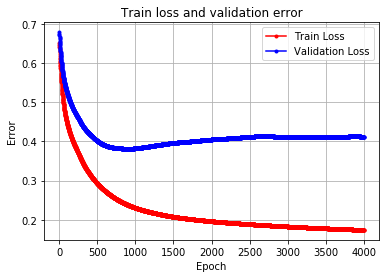

```python
#run_hist_1.history.keys()

plt.plot(run_hist_1.history["loss"],'r', marker='.', label="Train Loss")
plt.plot(run_hist_1.history["val_loss"],'b', marker='.', label="Validation Loss")
plt.title("Train loss and validation error")
plt.legend()
plt.xlabel('Epoch'), plt.ylabel('Error')
plt.grid()
```

What can be oberved form the plot? Why would we might be interested in having longer training phase?

### Student task 1:

- Learn more about [Dense](https://keras.io/layers/core/) layer, available [activation function](https://keras.io/activations/) and [optimizers](https://keras.io/optimizers/),
- Build neural network with more then 4 layers having different activation function in each layer. Train it and visual the results.

```
Model: "sequential_29"
_________________________________________________________________
Layer (type)                 Output Shape              Param #
=================================================================
dense_151 (Dense)            (None, 22)                506
_________________________________________________________________
dense_152 (Dense)            (None, 11)                253
_________________________________________________________________
dense_153 (Dense)            (None, 5)                 60
_________________________________________________________________
dense_154 (Dense)            (None, 3)                 18
_________________________________________________________________
dense_155 (Dense)            (None, 1)                 4
=================================================================
Total params: 841
Trainable params: 841
Non-trainable params: 0
_________________________________________________________________
Trenowanie sieci neuronowej

Dokładność danych TREnujących:  1.0
Dokładność dla danych TESTujących:  0.9152542372881356
[[10  5]
 [ 0 44]]
```

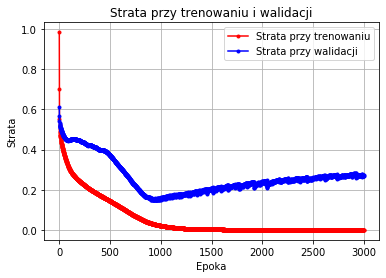

```python
from keras.models import Sequential
from keras.layers import Dense, Activation
from keras.optimizers import SGD

#zadanie 1
#wczytanie i przygotowanie danych
url = "https://archive.ics.uci.edu/ml/machine-learning-databases/parkinsons/parkinsons.data"
names = ["name","MDVP:Fo(Hz)","MDVP:Fhi(Hz)","MDVP:Flo(Hz)","MDVP:Jitter(%)","MDVP:Jitter(Abs)","MDVP:RAP","MDVP:PPQ",
         "Jitter:DDP","MDVP:Shimmer","MDVP:Shimmer(dB)","Shimmer:APQ3","Shimmer:APQ5","MDVP:APQ","Shimmer:DDA",
         "NHR","HNR","status","RPDE","DFA","spread1","spread2","D2","PPE"]

parkinson_df = pd.read_csv(url, names=names) #load CVS data

#load Pandas Dataframe into numpy arrays; Data to zbiór cech, target to szukana cecha
data = parkinson_df.loc[1:,["MDVP:Fo(Hz)","MDVP:Fhi(Hz)","MDVP:Flo(Hz)","MDVP:Jitter(%)","MDVP:Jitter(Abs)","MDVP:RAP","MDVP:PPQ",
         "Jitter:DDP","MDVP:Shimmer","MDVP:Shimmer(dB)","Shimmer:APQ3","Shimmer:APQ5","MDVP:APQ","Shimmer:DDA",
         "NHR","HNR","RPDE","DFA","spread1","spread2","D2","PPE"]].values.astype(np.float)

target = parkinson_df.loc[1:, ['status']].values.astype(np.float)

#standarise data
data = StandardScaler().fit_transform(data)

#zbiory testujące i uczące
data_train, data_test, target_train, target_test = \
train_test_split(data, target, test_size=0.3, random_state=545)

# #Build neural network with Keras using Sequential model
# neural_model = Sequential([
#     Dense(22, input_shape=(22,), activation="relu"),
#     Dense(16, activation="tanh"),
#     Dense(8, activation="sigmoid"),
#     Dense(4, activation="linear"),
#     Dense(1, activation="softmax"),
#     #Dense(1, activation="exponential")
# ])

neural_model = Sequential([
    Dense(22, input_shape=(22,), activation="relu"),
    Dense(11, activation="elu"),
    Dense(5, activation="softmax"),
    Dense(3, activation="exponential"),
    Dense(1, activation="tanh")
])
# neural_model = Sequential([
#     Dense(22, input_shape=(22,), activation="relu"),
#     Dense(16, activation="softmax"),
#     Dense(8, activation="elu"),
#     Dense(4, activation="tanh"),
#     Dense(1, activation="sigmoid")
# ])

#podgląd architektury sieci ; Layer (type); Output Shape ; Param - tabelka
neural_model.summary()

#Training neural model
neural_model.compile(SGD(lr = .003), "binary_crossentropy", metrics=["accuracy"])

np.random.seed(0)

#historia trenowania
run_hist_1 = neural_model.fit(data_train, target_train, epochs=3000,\
                              validation_data=(data_test, target_test), \
                              verbose=False, shuffle=False)

print("Trenowanie sieci neuronowej\n")

print('Dokładność danych TREnujących: ', \
      accuracy_score(target_train, neural_model.predict_classes(data_train)))

print('Dokładność dla danych TESTujących: ', \
      accuracy_score(target_test, neural_model.predict_classes(data_test)))


conf_matrix = confusion_matrix(target_test, neural_model.predict_classes(data_test))
print(conf_matrix)

#WIZUALIZACJA

plt.plot(run_hist_1.history["loss"],'r', marker='.', label="Strata przy trenowaniu")
plt.plot(run_hist_1.history["val_loss"],'b', marker='.', label="Strata przy walidacji")
plt.title("Strata przy trenowaniu i walidacji")
plt.legend()
plt.xlabel('Epoka'), plt.ylabel('Strata')
plt.grid()
```

[figure not shown]

```python
plt.plot(run_hist_1.history["accuracy"],'r', label="Dokladnosc trenowania")
plt.plot(run_hist_1.history["val_accuracy"],'b', label="Dokladnosc walidacji")
plt.title("Dokładnosc trenowania i walidacji")
plt.legend()
plt.xlabel('Epoki'), plt.ylabel('Straty')
plt.grid()
```

### Build neural network with Keras using Sequential model with Dropout

```python
#model with dropouts

neural_network_d = Sequential()
neural_network_d.add(Dense(2, activation='relu', input_shape=(22,)))
neural_network_d.add(Dropout(0.1))
#neural_network_d.add(Dense(2, activation='relu'))
#neural_network_d.add(Dropout(0.1))
neural_network_d.add(Dense(1, activation='sigmoid'))

neural_network_d.summary()
```

[output not shown]

```python
neural_network_d.compile(SGD(lr = .003), "binary_crossentropy", metrics=["accuracy"])

run_hist_2 = neural_network_d.fit(data_train, target_train, epochs=4000, \
                                  validation_data=(data_test, target_test), \
                                  verbose=False, shuffle=False)

print("Training neural network w dropouts..\n")

print('Accuracy over training data is ', accuracy_score(target_train, \
                                                        neural_network_d.predict_classes(data_train)))

print('Accuracy over testing data is ', accuracy_score(target_test, \
                                                       neural_network_d.predict_classes(data_test)))
```

```
Training neural network w dropouts..

Accuracy over training data is  0.9117647058823529
Accuracy over testing data is  0.8135593220338984
```

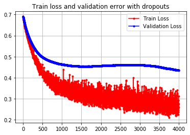

```python
plt.plot(run_hist_2.history["loss"],'r', marker='.', label="Train Loss")
plt.plot(run_hist_2.history["val_loss"],'b', marker='.', label="Validation Loss")
plt.title("Train loss and validation error with dropouts")
plt.legend()
plt.grid()
```

What is the benefits of using dropouts?

### Student task 2

- Add dropouts to neural network from task 1 and compere the results.

```python
Żeby nie dopuścić do zbyt dużego dopasowania budowanego modelu do danych uczących, ale uczenie trwa dłużej
```

```
Model: "sequential_37"
_________________________________________________________________
Layer (type)                 Output Shape              Param #
=================================================================
dense_191 (Dense)            (None, 22)                506
_________________________________________________________________
dropout_41 (Dropout)         (None, 22)                0
_________________________________________________________________
dense_192 (Dense)            (None, 11)                253
_________________________________________________________________
dropout_42 (Dropout)         (None, 11)                0
_________________________________________________________________
dense_193 (Dense)            (None, 5)                 60
_________________________________________________________________
dropout_43 (Dropout)         (None, 5)                 0
_________________________________________________________________
dense_194 (Dense)            (None, 3)                 18
_________________________________________________________________
dropout_44 (Dropout)         (None, 3)                 0
_________________________________________________________________
dense_195 (Dense)            (None, 1)                 4
=================================================================
Total params: 841
Trainable params: 841
Non-trainable params: 0
_________________________________________________________________
Model: "sequential_36"
_________________________________________________________________
Layer (type)                 Output Shape              Param #
=================================================================
dense_186 (Dense)            (None, 22)                506
_________________________________________________________________
dense_187 (Dense)            (None, 11)                253
_________________________________________________________________
dense_188 (Dense)            (None, 5)                 60
_________________________________________________________________
dense_189 (Dense)            (None, 3)                 18
_________________________________________________________________
dense_190 (Dense)            (None, 1)                 4
=================================================================
Total params: 841
Trainable params: 841
Non-trainable params: 0
_________________________________________________________________
Trenowanie sieci neuronowej

Dokładność danych TREnujących:  1.0
Dokładność dla danych TESTujących:  0.9152542372881356
[[10  5]
 [ 0 44]]
```

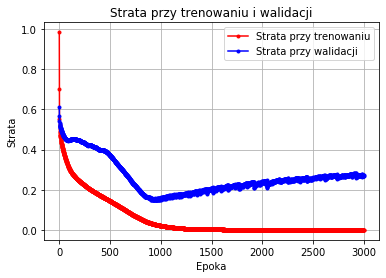

```python
#zadanie 2 to zad 1 + dropouty

#wczytanie i przygotowanie danych
url = "https://archive.ics.uci.edu/ml/machine-learning-databases/parkinsons/parkinsons.data"
names = ["name","MDVP:Fo(Hz)","MDVP:Fhi(Hz)","MDVP:Flo(Hz)","MDVP:Jitter(%)","MDVP:Jitter(Abs)","MDVP:RAP","MDVP:PPQ",
         "Jitter:DDP","MDVP:Shimmer","MDVP:Shimmer(dB)","Shimmer:APQ3","Shimmer:APQ5","MDVP:APQ","Shimmer:DDA",
         "NHR","HNR","status","RPDE","DFA","spread1","spread2","D2","PPE"]

parkinson_df = pd.read_csv(url, names=names) #load CVS data

#load Pandas Dataframe into numpy arrays; Data to zbiór cech, target to szukana cecha
data = parkinson_df.loc[1:,["MDVP:Fo(Hz)","MDVP:Fhi(Hz)","MDVP:Flo(Hz)","MDVP:Jitter(%)","MDVP:Jitter(Abs)","MDVP:RAP","MDVP:PPQ",
         "Jitter:DDP","MDVP:Shimmer","MDVP:Shimmer(dB)","Shimmer:APQ3","Shimmer:APQ5","MDVP:APQ","Shimmer:DDA",
         "NHR","HNR","RPDE","DFA","spread1","spread2","D2","PPE"]].values.astype(np.float)
target = parkinson_df.loc[1:, ['status']].values.astype(np.float)

#standarise data
data = StandardScaler().fit_transform(data)

#zbiory testujące i uczące
data_train, data_test, target_train, target_test = \
train_test_split(data, target, test_size=0.3, random_state=545)

# #Build neural network with Keras using Sequential model
# neural_model = Sequential([
#     Dense(22, input_shape=(22,), activation="relu"),
#     Dense(16, activation="tanh"),
#     Dense(8, activation="sigmoid"),
#     Dense(4, activation="linear"),
#     Dense(2, activation="softmax"),
#     Dense(1, activation="exponential")
# ])

neural_model = Sequential([
    Dense(22, input_shape=(22,), activation="relu"),
    Dense(11, activation="elu"),
    Dense(5, activation="softmax"),
    Dense(3, activation="exponential"),
    Dense(1, activation="tanh")
])
#model with dropouts

neural_network_d = Sequential()
neural_network_d.add(Dense(22, activation='relu', input_shape=(22,)))
neural_network_d.add(Dropout(0.1))
neural_network_d.add(Dense(11, activation='elu'))
neural_network_d.add(Dropout(0.5))
neural_network_d.add(Dense(5, activation='softmax'))
neural_network_d.add(Dropout(0.4))
neural_network_d.add(Dense(3, activation='exponential'))
neural_network_d.add(Dropout(0.2))
neural_network_d.add(Dense(1, activation='tanh'))

neural_network_d.summary()
#rate: float between 0 and 1. Fraction of the input units to drop.
# model = Sequential()
# 	model.add(Dense(60, input_dim=60, activation='relu'))
# 	model.add(Dense(30,  activation='relu'))
# 	model.add(Dense(1, activation='sigmoid'))





#podgląd architektury sieci ; Layer (type); Output Shape ; Param - tabelka
neural_model.summary()

#Training neural model
neural_model.compile(SGD(lr = .003), "binary_crossentropy", metrics=["accuracy"])

np.random.seed(0)

#historia trenowania
run_hist_3 = neural_model.fit(data_train, target_train, epochs=3000,\
                              validation_data=(data_test, target_test), \
                              verbose=False, shuffle=False)

print("Trenowanie sieci neuronowej\n")

print('Dokładność danych TREnujących: ', \
      accuracy_score(target_train, neural_model.predict_classes(data_train)))

print('Dokładność dla danych TESTujących: ', \
      accuracy_score(target_test, neural_model.predict_classes(data_test)))


conf_matrix = confusion_matrix(target_test, neural_model.predict_classes(data_test))
print(conf_matrix)

#WIZUALIZACJA

plt.plot(run_hist_1.history["loss"],'r', marker='.', label="Strata przy trenowaniu")
plt.plot(run_hist_1.history["val_loss"],'b', marker='.', label="Strata przy walidacji")
plt.title("Strata przy trenowaniu i walidacji")
plt.legend()
plt.xlabel('Epoka'), plt.ylabel('Strata')
plt.grid()
```

[figure not shown]

```python
plt.plot(run_hist_3.history["loss"],'r', marker='.', label="Train Loss")
plt.plot(run_hist_3.history["val_loss"],'b', marker='.', label="Validation Loss")
plt.title("Train loss and validation error with dropouts")
plt.legend()
plt.grid()
```

# Neural network for multiclass classification on mnist data

```python
#cztery tablice Numpy
from keras.datasets import mnist
(x_train, y_train), (x_test, y_test) = mnist.load_data()
```

```python
images_train =  []
for image_train in x_train:
    images_train.append(image_train.flatten())

images_test = []

for image_test in x_test:
    images_test.append(image_test.flatten())

images_train = np.array(images_train)
images_test = np.array(images_test)

from keras.utils import normalize
images_train = normalize(images_train)
images_test = normalize(images_test)


from keras.utils.np_utils import to_categorical

y_train_categorical = to_categorical(y_train)
y_test_categorical = to_categorical(y_test)
```

```python
neural_network_mnist = Sequential()
neural_network_mnist.add(Dense(50, activation='relu', input_shape=(784,)))
#neural_network_mnist.add(Dense(20, activation='relu'))
#neural_network_mnist.add(Dropout(0.01))
neural_network_mnist.add(Dense(10, activation='softmax'))

neural_network_mnist.summary()

sgd = SGD(lr=0.1, decay=1e-6, momentum=0.9)
neural_network_mnist.compile(optimizer=sgd, loss="categorical_crossentropy", \
                             metrics=["accuracy"])

run_hist_4 = neural_network_mnist.fit(images_train, y_train_categorical, epochs=20, \
                                  validation_data=(images_test, y_test_categorical), \
                                  verbose=True, shuffle=False)
```

```
Model: "sequential_2"
_________________________________________________________________
Layer (type)                 Output Shape              Param #
=================================================================
dense_3 (Dense)              (None, 50)                39250
_________________________________________________________________
dense_4 (Dense)              (None, 10)                510
=================================================================
Total params: 39,760
Trainable params: 39,760
Non-trainable params: 0
_________________________________________________________________
Train on 60000 samples, validate on 10000 samples
```

```python
from keras.models import Sequential
from keras.layers import Dense, Activation
from keras.optimizers import SGD
```

### Save neural model

```python
neural_network_mnist.save('mnist-model.h5')
```

### Visualizing training

[figure not shown]

```python
plt.plot(run_hist_3.history["loss"],'r', marker='.', label="Train Loss")
plt.plot(run_hist_3.history["val_loss"],'b', marker='.', label="Validation Loss")
plt.title("Train loss and validation error with dropouts")
plt.legend()
plt.grid()
```

### Load trained neural model

```python
from keras.models import load_model
model = load_model('mnist-model.h5')
```

```python
print("Model evaluation [loss, accu]: ", model.evaluate(images_test, y_test_categorical))
```

```
Model evaluation [loss, accu]:  [0.10845871762496535, 0.9718999862670898]
```

### Usage of a trained neural model

```
Neural netowrk predicts:
[[9.9246842e-01 6.2444073e-12 2.7866520e-06 1.1325267e-08 3.1683866e-03
  1.7495331e-05 2.2324254e-03 2.1103723e-03 5.9615285e-11 2.2932102e-08]]

Neural network recognized image as: 0
```

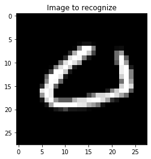

```python
id = 490

print("Neural netowrk predicts:")
print(model.predict(images_test[id,:].reshape(-1,784)))

plt.imshow(images_test[id,:].reshape(28,28), cmap=plt.get_cmap("gray"))
plt.title('Image to recognize')

print("\nNeural network recognized image as:", np.argmax(model.predict(images_test[id,:].reshape(-1,784))))
```

### Student task 3

Build **two** neural network based regression model to predict "Boston housing" price. One without dropouts and one with droputs. Remember to use aprioprate loss function and activation in output layer. Evaluate model and visual learning process. Experiments with different network architecture and optimization parameters. Use data from Keras library.

```
data train : (404, 13)     target train: (404,)
data test : (102, 13)      target test: (102,)
Model: "sequential_12"
_________________________________________________________________
Layer (type)                 Output Shape              Param #
=================================================================
dense_34 (Dense)             (None, 40)                560
_________________________________________________________________
dense_35 (Dense)             (None, 30)                1230
_________________________________________________________________
dense_36 (Dense)             (None, 1)                 31
=================================================================
Total params: 1,821
Trainable params: 1,821
Non-trainable params: 0
_________________________________________________________________
```

[figure not shown]

```python
from keras.datasets import boston_housing
from sklearn.model_selection import train_test_split

(x_train, y_train), (x_test, y_test) = boston_housing.load_data()

print("data train :",x_train.shape,"    target train:",y_train.shape)
print("data test :",x_test.shape,"     target test:",y_test.shape)

#standaryzacja
sc = StandardScaler()
data_train = sc.fit_transform(x_train)
data_test = sc.transform(x_test)

#model sieci neuronowej bez użycia dropoutów
#ważne że dla regresji musi być jedna jednostka bez funkcji aktywacji
model_bez_dropoutow = Sequential()
model_bez_dropoutow.add(Dense(40, activation='relu', input_shape=[x_train.shape[1]]))
model_bez_dropoutow.add(Dense(30,  activation='elu'))#'exponential'
model_bez_dropoutow.add(Dense(1, activation='linear'))

model_bez_dropoutow.summary()

#mse-błąd średniokwadratowy ; RMSprop-algorytm optymalizacji
model_bez_dropoutow.compile( loss='mse',optimizer='RMSprop', metrics=['mse'])


run_hist_5 = model_bez_dropoutow.fit(data_train, #cechy
                                  y_train,       #wektor docelowy
                                  epochs=30,    #liczba epok
                                  validation_data=(data_test, y_test),  # dane testowe
                                  verbose=0,        #dane wyjsciowe
                                  shuffle=False)

#wizualizacja - najlepiej nauczony model ok 15 epoka, bo jak było 100 epok to straty utrzymywały się na równym poziomie

plt.plot(run_hist_5.history["loss"],'r', label="Strata trenowania")
plt.plot(run_hist_5.history["val_loss"], label="Strata walidacji")
plt.title("Strata trenowania i walidacji z dropoutem")
plt.legend()
plt.xlabel('Epoki'),
plt.ylabel('Straty')
plt.grid()
```

```
Model: "sequential_36"
_________________________________________________________________
Layer (type)                 Output Shape              Param #
=================================================================
dense_106 (Dense)            (None, 40)                560
_________________________________________________________________
dropout_31 (Dropout)         (None, 40)                0
_________________________________________________________________
dense_107 (Dense)            (None, 30)                1230
_________________________________________________________________
dense_108 (Dense)            (None, 1)                 31
=================================================================
Total params: 1,821
Trainable params: 1,821
Non-trainable params: 0
_________________________________________________________________
```

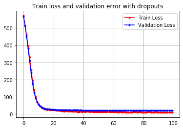

```python
#Model z dropoutami

#model sieci neuronowej bez użycia dropoutów
#ważne że dla regresji musi być jedna jednostka bez funkcji aktywacji
model_z_dropoutami = Sequential()
model_z_dropoutami.add(Dense(40, activation='relu', input_shape=[x_train.shape[1]]))
model_z_dropoutami.add(Dropout(0.1))
model_z_dropoutami.add(Dense(30,  activation='elu'))#'exponential'
#model_z_dropoutami.add(Dropout(0.2))
model_z_dropoutami.add(Dense(1, activation='linear'))


model_z_dropoutami.summary()

#mse-błąd średniokwadratowy- kwadrat różnicy między wartościami przewidywanymi przez
#sieć i wartościami docelowymi; RMSprop-algorytm optymalizacji
model_z_dropoutami.compile( loss='mse',optimizer='RMSprop', metrics=['mse'])


run_hist_6 = model_z_dropoutami.fit(data_train, #cechy
                                  y_train,       #wektor docelowy
                                  epochs=100,    #liczba epok
                                  validation_data=(data_test, y_test),  # dane testowe
                                  verbose=0,        #dane wyjsciowe
                                  shuffle=False)

#wizualizacja - najlepiej nauczony model ok 15 epoka, bo jak było 100 epok to straty utrzymywały się na równym poziomie

plt.plot(run_hist_6.history["loss"],'r', marker='.', label="Train Loss")
plt.plot(run_hist_6.history["val_loss"],'b', marker='.', label="Validation Loss")
plt.title("Train loss and validation error with dropouts")
plt.legend()
plt.grid()
```

```
Model: "sequential_39"
_________________________________________________________________
Layer (type)                 Output Shape              Param #
=================================================================
dense_115 (Dense)            (None, 40)                560
_________________________________________________________________
dropout_34 (Dropout)         (None, 40)                0
_________________________________________________________________
dense_116 (Dense)            (None, 30)                1230
_________________________________________________________________
dense_117 (Dense)            (None, 1)                 31
=================================================================
Total params: 1,821
Trainable params: 1,821
Non-trainable params: 0
_________________________________________________________________
```

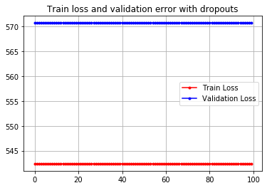

```python
#Model z dropoutami - ŹLE - udowodnienie że bez jednej funcji aktywacji liniowej przy regresji jest źle

#model sieci neuronowej bez użycia dropoutów
#ważne że dla regresji musi być jedna jednostka bez funkcji aktywacji
model_z_dropoutami = Sequential()
model_z_dropoutami.add(Dense(40, activation='relu', input_shape=[x_train.shape[1]]))
model_z_dropoutami.add(Dropout(0.1))
model_z_dropoutami.add(Dense(30,  activation='elu'))#'exponential'
#model_z_dropoutami.add(Dropout(0.2))
model_z_dropoutami.add(Dense(1, activation='softmax'))


model_z_dropoutami.summary()

#mse-błąd średniokwadratowy- kwadrat różnicy między wartościami przewidywanymi przez
#sieć i wartościami docelowymi; RMSprop-algorytm optymalizacji
model_z_dropoutami.compile( loss='mse',optimizer='RMSprop', metrics=['mse'])


run_hist_6 = model_z_dropoutami.fit(data_train, #cechy
                                  y_train,       #wektor docelowy
                                  epochs=100,    #liczba epok
                                  validation_data=(data_test, y_test),  # dane testowe
                                  verbose=0,        #dane wyjsciowe
                                  shuffle=False)

#wizualizacja - najlepiej nauczony model ok 15 epoka, bo jak było 100 epok to straty utrzymywały się na równym poziomie

plt.plot(run_hist_6.history["loss"],'r', marker='.', label="Train Loss")
plt.plot(run_hist_6.history["val_loss"],'b', marker='.', label="Validation Loss")
plt.title("Train loss and validation error with dropouts")
plt.legend()
plt.grid()
```

softmax - źle